```python
import os
import numpy as np
import pandas as pd
import matplotlib.pyplot as plt
```

# Getting the Data

```python
FILE_PATH = os.path.join(os.getcwd(),'Assignment#1_Performance_track_records.csv')

data = pd.read_csv(FILE_PATH)
```

```python
daily_return = data.drop(columns=['Asset', 'DateTime', 'Price_Close'])
daily_return['DateTime'] = pd.to_datetime(data['DateTime'])

daily_return = daily_return.set_index('DateTime')
```

```python
daily_return.head()
```

| DateTime | 03_01 | 03_02 | 03_03 | 03_04 | 03_05 | 03_06 | 03_07 | 03_08 | 03_09 | 03_10 | ... | 01_03 | 01_04 | 01_05 | 01_06 | 01_07 | 01_08 | 01_09 | 01_10 | 01_11 | 01_12 |
| --- | --- | --- | --- | --- | --- | --- | --- | --- | --- | --- | --- | --- | --- | --- | --- | --- | --- | --- | --- | --- | --- |
| 2014-01-01 17:00:00 | 0.0 | 0.0 | 0.0 | 0.0 | 0.0 | 0.0 | 0.0 | 0.0 | 0.0 | 0.0 | ... | 0.0 | 0.0 | 0.0 | 0.0 | 0.0 | 0.0 | 0.000000 | 0.000000 | 0.0 | 0.0 |
| 2014-01-02 17:00:00 | 0.0 | 0.0 | 0.0 | 0.0 | 0.0 | 0.0 | 0.0 | 0.0 | 0.0 | 0.0 | ... | 0.0 | 0.0 | 0.0 | 0.0 | 0.0 | 0.0 | 0.000000 | 0.000000 | 0.0 | 0.0 |
| 2014-01-03 17:00:00 | 0.0 | 0.0 | 0.0 | 0.0 | 0.0 | 0.0 | 0.0 | 0.0 | 0.0 | 0.0 | ... | 0.0 | 0.0 | 0.0 | 0.0 | 0.0 | 0.0 | 0.000000 | 0.000000 | 0.0 | 0.0 |
| 2014-01-06 17:00:00 | 0.0 | 0.0 | 0.0 | 0.0 | 0.0 | 0.0 | 0.0 | 0.0 | 0.0 | 0.0 | ... | 0.0 | 0.0 | 0.0 | 0.0 | 0.0 | 0.0 | -0.000899 | 0.000000 | 0.0 | 0.0 |
| 2014-01-07 17:00:00 | 0.0 | 0.0 | 0.0 | 0.0 | 0.0 | 0.0 | 0.0 | 0.0 | 0.0 | 0.0 | ... | 0.0 | 0.0 | 0.0 | 0.0 | 0.0 | 0.0 | -0.005002 | -0.006569 | 0.0 | 0.0 |

5 rows × 24 columns

# Performance Analysis

## Cumulative Return

```python
cum_return = (daily_return + 1).cumprod()
```

**The Total Returns of all strategies are listed below.**

```python
total_return = (daily_return + 1).prod() - 1
total_return.sort_values(ascending=False)
```

```
01_12    0.198706
03_04    0.189177
01_06    0.187727
03_12    0.183601
03_11    0.176096
03_06    0.176042
03_01    0.167860
01_04    0.160769
03_03    0.159345
03_05    0.155785
01_03    0.147417
01_11    0.140965
01_10    0.131031
01_05    0.130992
03_02    0.130634
01_07    0.125945
01_01    0.123725
01_08    0.122967
03_10    0.122736
01_09    0.117492
01_02    0.112921
03_08    0.111033
03_09    0.104909
03_07    0.094534
dtype: float64
```

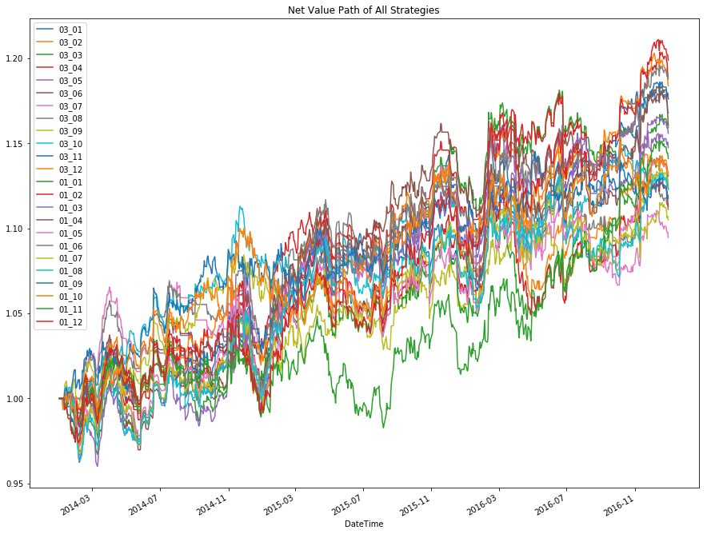

```python
cum_return.plot(figsize=(15,12), title='Net Value Path of All Strategies')
```

## Annualized Return

**The Annualized Returns of all strategies are listed below.**

```python
annualized_return = pow(total_return+1, 1/3) - 1
display(annualized_return.sort_values(ascending=False))
```

```
01_12    0.062277
03_04    0.059454
01_06    0.059023
03_12    0.057796
03_11    0.055555
03_06    0.055539
03_01    0.053085
01_04    0.050950
03_03    0.050520
03_05    0.049443
01_03    0.046905
01_11    0.044939
01_10    0.041897
01_05    0.041885
03_02    0.041775
01_07    0.040333
01_01    0.039649
01_08    0.039415
03_10    0.039344
01_09    0.037723
01_02    0.036306
03_08    0.035720
03_09    0.033813
03_07    0.030567
dtype: float64
```

## Annualized Volatility

**The Annualized Volatility of all strategies are listed below.**

```python
annualized_vol = daily_return.std() * np.sqrt(250)
display(annualized_vol.sort_values(ascending=False))
```

```
01_03    0.063637
01_05    0.062591
01_07    0.062304
01_08    0.061977
01_02    0.061669
01_01    0.061434
01_04    0.061184
01_11    0.061004
01_10    0.060845
01_06    0.060609
03_03    0.058850
01_12    0.058752
01_09    0.055905
03_04    0.055351
03_02    0.055336
03_01    0.054881
03_10    0.054692
03_05    0.054145
03_07    0.053802
03_06    0.053626
03_11    0.053578
03_12    0.053237
03_08    0.053062
03_09    0.052234
dtype: float64
```

## Sharpe Ratio

**We use 10 year treasury rate as the risk free rate to calculate their Sharpe Ratios.**  
Source: https://www.multpl.com/10-year-treasury-rate/table/by-year

```python
rf_2014 = 0.0286
rf_2015 = 0.0188
rf_2016 = 0.0209
```

```python
rf = pow((1+rf_2014)*(1+rf_2015)*(1+rf_2016), 1/3) - 1
```

**The Sharpe Ratios of all strategies are listed below.**

```python
sharpe_ratio = (annualized_return - rf) / annualized_vol
display(sharpe_ratio.sort_values(ascending=False))
```

```
01_12    0.672630
03_04    0.662970
03_12    0.658150
03_11    0.612138
03_06    0.611287
01_06    0.598348
03_01    0.552596
03_05    0.492853
03_03    0.471741
01_04    0.460767
01_03    0.379445
01_11    0.363595
03_02    0.343667
01_10    0.314556
01_05    0.305587
03_10    0.303258
01_07    0.282088
01_01    0.274945
01_08    0.268764
01_09    0.267683
03_08    0.244279
01_02    0.219691
03_09    0.211655
03_07    0.145153
dtype: float64
```

## Information Ratio

**We use S&P 500 yearly return as the benchmark to calculate Information Ratio**  
Source: https://ycharts.com/indicators/sandp_500_total_return_annual

```python
bm_2014 = 0.1369
bm_2015 = 0.0138
bm_2016 = 0.1196
```

```python
benchmark = pow((1+bm_2014)*(1+bm_2015)*(1+bm_2016), 1/3) - 1
```

**The Information Ratios of all strategies are listed below.**

```python
information_ratio = (annualized_return - benchmark) / annualized_vol
display(information_ratio.sort_values(ascending=False))
```

```
01_12   -0.449924
01_06   -0.489813
03_04   -0.528564
03_12   -0.580709
01_04   -0.617166
03_06   -0.618574
03_11   -0.618823
03_03   -0.648959
03_01   -0.649133
01_03   -0.656950
01_11   -0.717525
03_05   -0.725232
01_05   -0.748114
01_10   -0.769395
01_07   -0.776476
01_08   -0.795391
01_01   -0.798608
03_02   -0.848193
01_02   -0.849769
03_10   -0.902643
01_09   -0.912037
03_08   -0.998653
03_09   -1.050992
03_07   -1.080697
dtype: float64
```

## Maximum Drawdown

```python
max_dd = ((cum_return.cummax() - cum_return) / cum_return.cummax()).max()
display(max_dd.sort_values(ascending=False))
```

```
01_02    0.071386
03_02    0.068913
01_01    0.066379
01_05    0.062652
01_11    0.062531
03_07    0.061697
03_09    0.060336
03_08    0.056548
01_12    0.056290
01_04    0.056010
03_12    0.055112
01_07    0.054781
03_01    0.053768
01_08    0.053671
01_10    0.051664
01_06    0.050497
03_03    0.047703
03_06    0.047352
03_10    0.047237
01_03    0.046024
03_05    0.045578
03_11    0.044149
03_04    0.042755
01_09    0.036525
dtype: float64
```

```python
df = pd.concat([total_return, annualized_return, annualized_vol,
           sharpe_ratio, information_ratio, max_dd], axis=1)
df.columns = ['Total Return', 'Annualized Return', 'Annualized Volatility',
                  'Sharpe Ratio', 'Information Ratio', 'Max Drawdown']
```

```python
display(df)
```

|  | Total Return | Annualized Return | Annualized Volatility | Sharpe Ratio | Information Ratio | Max Drawdown |
| --- | --- | --- | --- | --- | --- | --- |
| 03_01 | 0.167860 | 0.053085 | 0.054881 | 0.552596 | -0.649133 | 0.053768 |
| 03_02 | 0.130634 | 0.041775 | 0.055336 | 0.343667 | -0.848193 | 0.068913 |
| 03_03 | 0.159345 | 0.050520 | 0.058850 | 0.471741 | -0.648959 | 0.047703 |
| 03_04 | 0.189177 | 0.059454 | 0.055351 | 0.662970 | -0.528564 | 0.042755 |
| 03_05 | 0.155785 | 0.049443 | 0.054145 | 0.492853 | -0.725232 | 0.045578 |
| 03_06 | 0.176042 | 0.055539 | 0.053626 | 0.611287 | -0.618574 | 0.047352 |
| 03_07 | 0.094534 | 0.030567 | 0.053802 | 0.145153 | -1.080697 | 0.061697 |
| 03_08 | 0.111033 | 0.035720 | 0.053062 | 0.244279 | -0.998653 | 0.056548 |
| 03_09 | 0.104909 | 0.033813 | 0.052234 | 0.211655 | -1.050992 | 0.060336 |
| 03_10 | 0.122736 | 0.039344 | 0.054692 | 0.303258 | -0.902643 | 0.047237 |
| 03_11 | 0.176096 | 0.055555 | 0.053578 | 0.612138 | -0.618823 | 0.044149 |
| 03_12 | 0.183601 | 0.057796 | 0.053237 | 0.658150 | -0.580709 | 0.055112 |
| 01_01 | 0.123725 | 0.039649 | 0.061434 | 0.274945 | -0.798608 | 0.066379 |
| 01_02 | 0.112921 | 0.036306 | 0.061669 | 0.219691 | -0.849769 | 0.071386 |
| 01_03 | 0.147417 | 0.046905 | 0.063637 | 0.379445 | -0.656950 | 0.046024 |
| 01_04 | 0.160769 | 0.050950 | 0.061184 | 0.460767 | -0.617166 | 0.056010 |
| 01_05 | 0.130992 | 0.041885 | 0.062591 | 0.305587 | -0.748114 | 0.062652 |
| 01_06 | 0.187727 | 0.059023 | 0.060609 | 0.598348 | -0.489813 | 0.050497 |
| 01_07 | 0.125945 | 0.040333 | 0.062304 | 0.282088 | -0.776476 | 0.054781 |
| 01_08 | 0.122967 | 0.039415 | 0.061977 | 0.268764 | -0.795391 | 0.053671 |
| 01_09 | 0.117492 | 0.037723 | 0.055905 | 0.267683 | -0.912037 | 0.036525 |
| 01_10 | 0.131031 | 0.041897 | 0.060845 | 0.314556 | -0.769395 | 0.051664 |
| 01_11 | 0.140965 | 0.044939 | 0.061004 | 0.363595 | -0.717525 | 0.062531 |
| 01_12 | 0.198706 | 0.062277 | 0.058752 | 0.672630 | -0.449924 | 0.056290 |

# Strategies Ranking

**The 5 strategies we are going to compare are `03_04`, `03_06`, `03_12`, `01_02`,and `01_09`.**

```python
df.loc[['03_04', '03_06', '03_12', '01_02', '01_09']]
```

|  | Total Return | Annualized Return | Annualized Volatility | Sharpe Ratio | Information Ratio | Max Drawdown |
| --- | --- | --- | --- | --- | --- | --- |
| 03_04 | 0.189177 | 0.059454 | 0.055351 | 0.662970 | -0.528564 | 0.042755 |
| 03_06 | 0.176042 | 0.055539 | 0.053626 | 0.611287 | -0.618574 | 0.047352 |
| 03_12 | 0.183601 | 0.057796 | 0.053237 | 0.658150 | -0.580709 | 0.055112 |
| 01_02 | 0.112921 | 0.036306 | 0.061669 | 0.219691 | -0.849769 | 0.071386 |
| 01_09 | 0.117492 | 0.037723 | 0.055905 | 0.267683 | -0.912037 | 0.036525 |

- From the result above, **03_04** did a pretty good job. It achieves the highest total return over 3 years, and its annualized return is also the highest among 5 strategies, at the same time it keeps a relatively low annualized volatility and maximum drawdown.
- The performance of **01_02** is the worst. Its total return and annualized return are the lowest, but its annualized volatility is the highest one. In a word, its return is low and the fluctuation is large. Its maximum drawdown is also not satisfying.
- **03_06** and **03_12** are quite similar. They both have about 18% total return and their annualized volatility are around 0.053. **03_12**'s sharpe ratio is only slightly larger than **03_06**'s, but **03_12**'s maximum drawdown is almost 1% larger than **03_06**'s, which is not acceptable. Thus, we think **03_06**'s performance is better than **03_12** in some worst situation.
- **01_09**'s return is the second worst, almost the same as **01_02**'s. But its Sharpe Ratio is slightly larger than **01_02**. And at the same time, its maximum drawdown is much smaller than **01_02**'s. Thus, we think its total performance is better than **01_02**.

**Thus, the ranking of the 5 strategies are:**  
**03_04 > 03_06 > 03_12 > 01_09 > 01_02**